# RVA_tutorial

Justin Pomeranz

8/1/2023

# Overview

This tutorial will show you how to calculate the rnage of variation (RVA) for selected metrics from group 2 of the IHA using flow data from the Colorado River before the construction of Glen Canyon Dam.

# Preliminaries

- Open RStudio
  - Make sure you are in your `ENVS433` project (look in the top right area of RStudio)
- Make sure you have a folder called `data` in your project and that you have the `pre_data.csv` file in your `data` folder.
- load the packages you need by running the following code:

```r
library(tidyverse)
library(RcppRoll)
```

## Load the data into R

If you have the correct file in your `data` folder, you can load it into R using the following command:

```r
pre <- read_csv("data/pre_data.csv")
```

- Check that the data was loaded correctly.

```r
pre
```

```
## # A tibble: 3,652 x 7
##    date         cfs     y     m     d j_date consecutive_date
##    <date>     <dbl> <dbl> <dbl> <dbl>  <dbl>            <dbl>
##  1 1930-01-01  4700  1930     1     1      1                1
##  2 1930-01-02  4600  1930     1     2      2                2
##  3 1930-01-03  4500  1930     1     3      3                3
##  4 1930-01-04  4600  1930     1     4      4                4
##  5 1930-01-05  5000  1930     1     5      5                5
##  6 1930-01-06  5600  1930     1     6      6                6
##  7 1930-01-07  5900  1930     1     7      7                7
##  8 1930-01-08  6000  1930     1     8      8                8
##  9 1930-01-09  6100  1930     1     9      9                9
## 10 1930-01-10  6400  1930     1    10     10               10
## # i 3,642 more rows
```

```r
# names of columns
names(pre)
```

```
## [1] "date"             "cfs"              "y"                "m"
## [5] "d"                "j_date"           "consecutive_date"
```

## RVA calculations

### Group 2

- Minimum and maximum flow values across different timeframe “windows”
  - Need to calculate min/max within a year first, and then average those values across years
  - end up with a single value for each metric
- We will only be calculating RVA for the min and max values from the 1-, 3-, and 7-day windows from group 2.

## Calculations

### Calculations Group 2

We have already learned how to calculate these metrics in the IHA tutorial. Now, we will expand upon that by calculating variation in these metrics. We will keep it simple and just calculate 1 standard deviation (SD).

#### 1-day values

As a reminder, the following code will calculate the 1-day values and store it in an object called `pre_g2_1d`

```r
pre_g2_1d <- pre %>%
  group_by(y) %>%
  summarise(min_1 = min(cfs),
            max_1 = max(cfs)) %>%
  summarise(m_min_1 = mean(min_1),
            m_max_1 = mean(max_1))
```

We can modify this code slighty to also calculate the SD for the min and max values.

```r
pre_g2_1d_sd <- pre %>%
  group_by(y) %>%
  summarise(min_1 = min(cfs),
            max_1 = max(cfs)) %>%
  summarise(m_min_1 = mean(min_1),
            sd_min_1 = sd(min_1),
            m_max_1 = mean(max_1),
            sd_max_1 = sd(max_1))

pre_g2_1d_sd
```

```
## # A tibble: 1 x 4
##   m_min_1 sd_min_1 m_max_1 sd_max_1
##     <dbl>    <dbl>   <dbl>    <dbl>
## 1    2459     893.   71820   27951.
```

- We now have a new data object called `pre_g2_1d_sd` which has the mean and sd for our 1-day minimum and maximum values.
- use the `mutate()` function to add and subtract 1 SD from the mean
- first, use `pivot_longer()` to change the data structure and make it easier to calculate

```r
pre_g2_1d_sd <- pre_g2_1d_sd %>%
  # make the data frame "longer"
  # this gets a 2-column data frame with the values and the description
  pivot_longer(cols = 1:4, names_to = "metric", values_to = "value") %>%
  # next, we separate the description column (cols = 1) into multiple pieces
  separate(col = 1, c("summary_stat", "range", "day-window")) %>%
  # now, we make the data frame wider so that the mean and sd value are in adjacent columns
  pivot_wider(id_cols = 2:3, names_from = 1) %>%
  # finally we can calc the low and hi range of the interval by
  # subtracting or adding the SD from the mean, respectively
  mutate(low_sd = m - sd,
         hi_sd = m+sd)

pre_g2_1d_sd
```

```
## # A tibble: 2 x 6
##   range `day-window`     m     sd low_sd  hi_sd
##   <chr> <chr>        <dbl>  <dbl>  <dbl>  <dbl>
## 1 min   1             2459   893.  1566.  3352.
## 2 max   1            71820 27951. 43869. 99771.
```

You can now see that the RVA for the 1-day minimum is between 1566 and 3352 CFS, and for the 1- day maximum it is between 43869 and 99770 CFS.

#### 3-day values

- This code is copied from the IHA tutorial

```r
# 3-day min and max
pre_g2_3d_sd <- pre %>%
  group_by(y) %>%
  reframe(mean_3 = roll_mean(cfs, n = 3)) %>%
  group_by(y) %>%
  summarise(min_3 = min(mean_3),
            max_3 = max(mean_3)) %>%
summarise(m_min_3 = mean(min_3),
          sd_min_3 = sd(min_3),
          m_max_3 = mean(max_3),
          sd_max_3 = sd(max_3))

pre_g2_3d_sd
```

```
## # A tibble: 1 x 4
##   m_min_3 sd_min_3 m_max_3 sd_max_3
##     <dbl>    <dbl>   <dbl>    <dbl>
## 1   2623.     866.  70207.   27394.
```

- re-format the data to calculate the interval range
- We can copy the code from the 1-day calculations above.
- **NOTE** that the only thing we need to change is the object to work with on the first line

```r
pre_g2_3d_sd %>%
  pivot_longer(cols = 1:4, names_to = "metric", values_to = "value") %>%
  separate(1, c("summary_stat", "range", "day-window")) %>%
  pivot_wider(2:3, names_from = 1) %>%
  mutate(low_sd = m - sd,
         hi_sd = m+sd)
```

```
## # A tibble: 2 x 6
##   range `day-window`      m     sd low_sd  hi_sd
##   <chr> <chr>         <dbl>  <dbl>  <dbl>  <dbl>
## 1 min   3             2623.   866.  1758.  3489.
## 2 max   3            70207. 27394. 42813. 97601.
```

#### 7-day values

We can repeat the process for the 7-day values.

- calculations copied from the IHA tutorial, with the sd calculations added

```r
# 7-day min and max
pre_g2_7d_sd <- pre %>%
  group_by(y) %>%
  reframe(mean_7 = roll_mean(cfs, n = 7)) %>%
  group_by(y) %>%
  summarise(min_7 = min(mean_7),
            max_7 = max(mean_7)) %>%
summarise(m_min_7 = mean(min_7),
          sd_min_7 = sd(min_7),
          m_max_7 = mean(max_7),
          sd_max_7 = sd(max_7))

pre_g2_7d_sd
```

```
## # A tibble: 1 x 4
##   m_min_7 sd_min_7 m_max_7 sd_max_7
##     <dbl>    <dbl>   <dbl>    <dbl>
## 1   2832.     909.  66714.   26276.
```

- and we can copy the code again from above, making sure to **CHANGE THE DATA OBJECT** in the first line.

```r
pre_g2_7d_sd %>%
  pivot_longer(cols = 1:4, names_to = "metric", values_to = "value") %>%
  separate(1, c("summary_stat", "range", "day-window")) %>%
  pivot_wider(2:3, names_from = 1) %>%
  mutate(low_sd = m - sd,
         hi_sd = m+sd)
```

```
## # A tibble: 2 x 6
##   range `day-window`      m     sd low_sd  hi_sd
##   <chr> <chr>         <dbl>  <dbl>  <dbl>  <dbl>
## 1 min   7             2832.   909.  1923.  3741.
## 2 max   7            66714. 26276. 40439. 92990.
```

### Plotting the RVA and CFS values

Recall the plot we made for the full pre-data set:

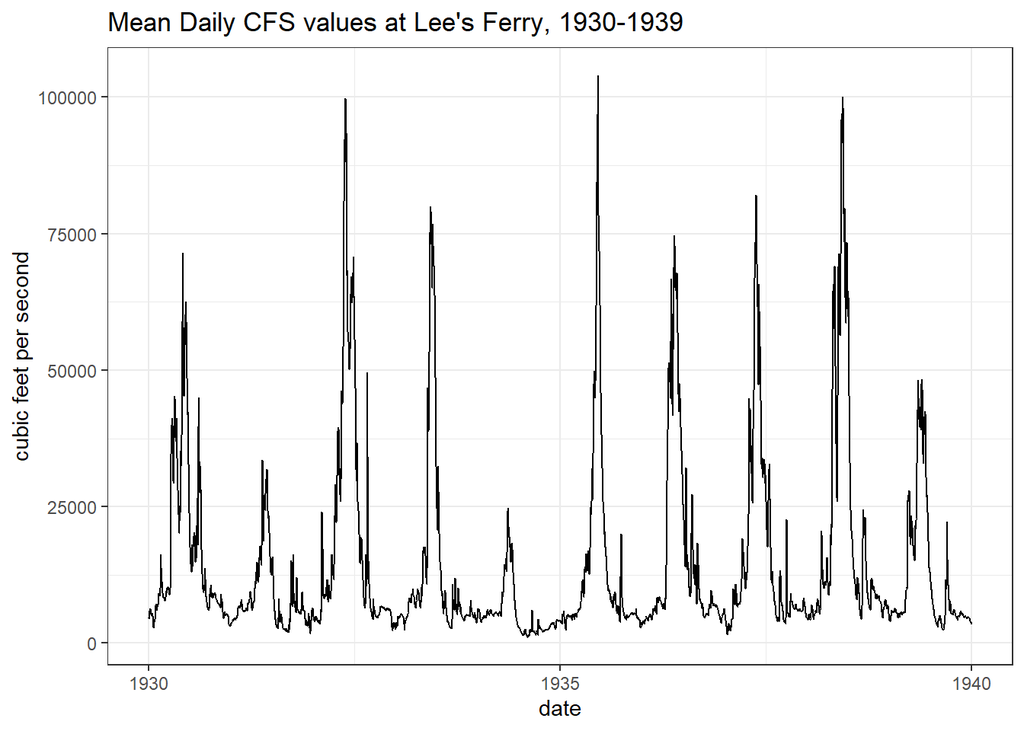

```r
ggplot(pre,
       aes(x = date,
           y = cfs)) +
  geom_line() +
  theme_bw() +
  labs(title = "Mean Daily CFS values at Lee's Ferry, 1930-1939",
       y = "cubic feet per second")
```

### 1-day minimums

Above, we showed that the RVA for the 1-day minimums was between 1566 and 3352 CFS.

- manually add lines at these values
- we can change the color and linetype for visualization
  - Google “ggplot2 line colors” and “ggplot2 line types” for options

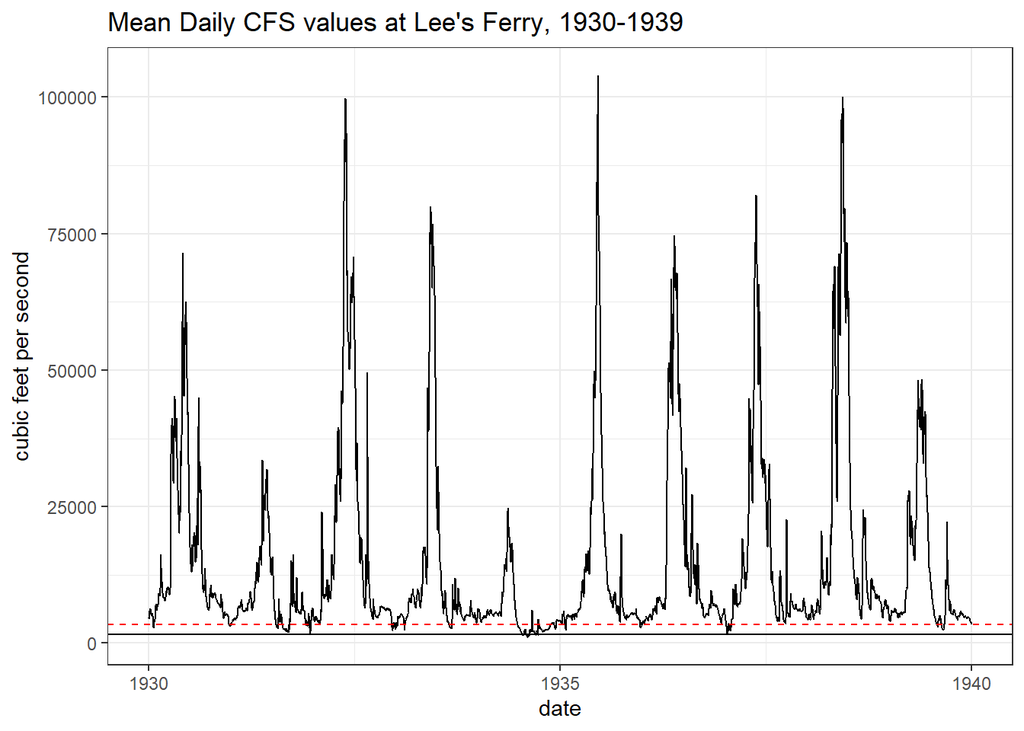

```r
# original plot copied from above
ggplot(pre,
       aes(x = date,
           y = cfs)) +
  geom_line() +
  theme_bw() +
  labs(title = "Mean Daily CFS values at Lee's Ferry, 1930-1939",
       y = "cubic feet per second") +
  # add another argument for the lower value
  geom_hline(yintercept = 1566) +
  # add another line for the upper range of the interval
  # change color and linetype for visualization
  geom_hline(yintercept = 3352,
             color = "red",
             linetype = "dashed")
```

- finally, we can “zoom” the plot to see the area we are interested in
- Note I’m also adding a caption to avoid confusion

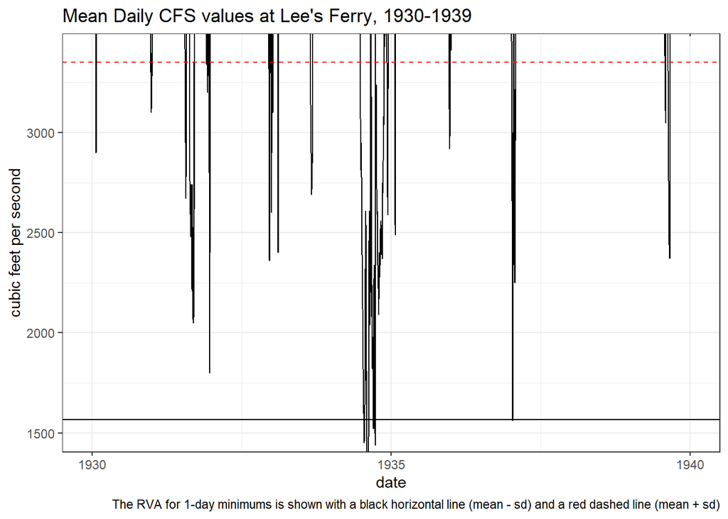

```r
# "Zoomed" plot
ggplot(pre,
       aes(x = date,
           y = cfs)) +
  geom_line() +
  theme_bw() +

  labs(title = "Mean Daily CFS values at Lee's Ferry, 1930-1939",
       y = "cubic feet per second",
       caption = "The RVA for 1-day minimums is shown with a black horizontal line (mean - sd) and a red dashed line (mean + sd)") +
  geom_hline(yintercept = 1566) +
  geom_hline(yintercept = 3352,
             color = "red",
             linetype = "dashed") +
  # set the y-range
  # make sure to go a little above and below your high and low values, respectively
  coord_cartesian(ylim = c(1500, 3400))
```

We can see that before the dam was closed, the annual low flows were mostly in the range we calculated before. There were a few low flow events which were below this value around late 1934, and possibly again in ~1937.

### 1-day maximums

- here is the full plot for the 1-day maximums.
- note that I have changed the arguments within the `yintercept` and `ylim = c()` arguments to match what was calculated above.
- I have also changed the caption to communicate the 1-day **MAXIMUM** values
- when you do this for the 3- and 7-day values, it is **CRITICAL** to change the values appropriately.
- I **will** subtract points from your assignment if the values and caption/title are incorrect.

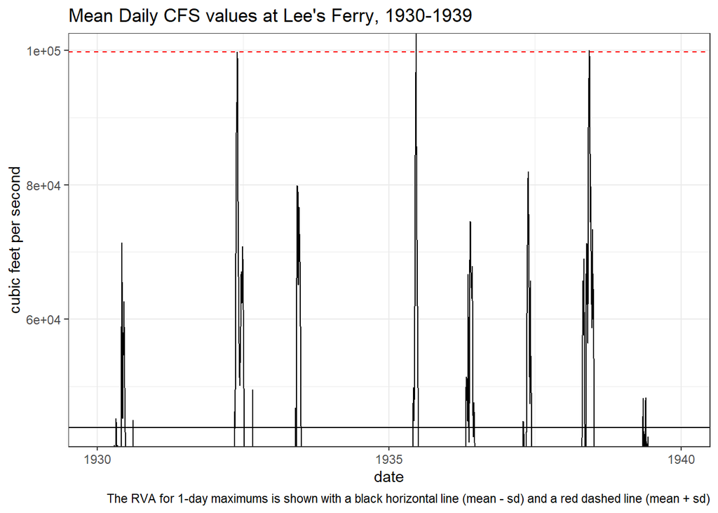

```r
# "Zoomed" plot
ggplot(pre,
       aes(x = date,
           y = cfs)) +
  geom_line() +
  theme_bw() +

  labs(title = "Mean Daily CFS values at Lee's Ferry, 1930-1939",
       y = "cubic feet per second",
       caption = "The RVA for 1-day maximums is shown with a black horizontal line (mean - sd) and a red dashed line (mean + sd)") +
  geom_hline(yintercept = 43869) +
  geom_hline(yintercept = 99770,
             color = "red",
             linetype = "dashed") +
  # set the y-range
  # make sure to go a little above and below your high and low values, respectively
  coord_cartesian(ylim = c(43800, 99800))
```

Once again, we can see that most (~8/10 years) were within or above the range of 1-day maximum values calculated above. This makes sense, since we are plotting the pre-data, and the flow of the Colorado river at this time was relatively unaffected.

- repeating the plot above, with a slighty bigger zoom window to see high flows ffrom each year

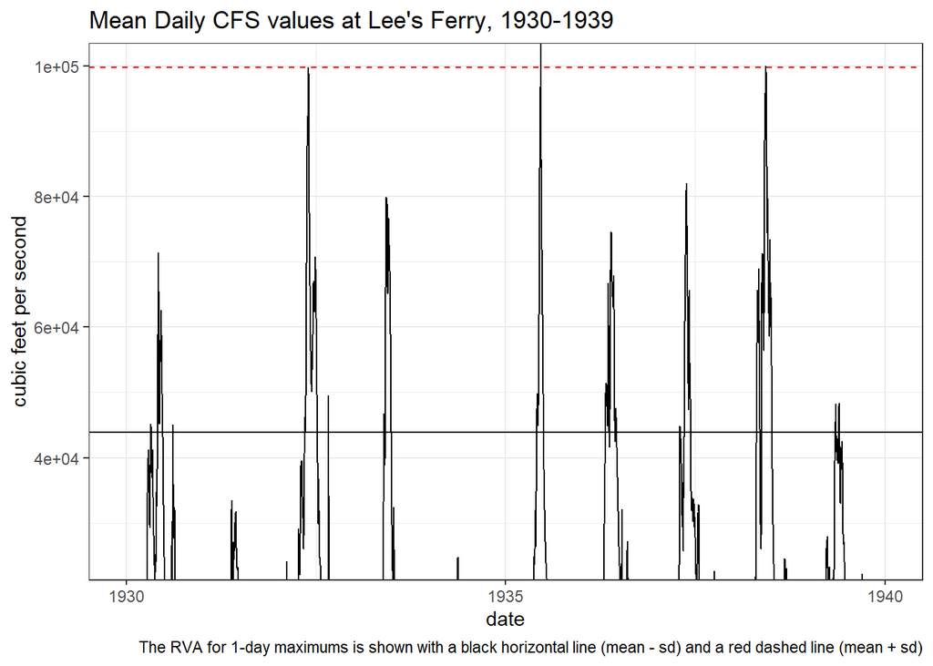

```r
# "Zoomed" plot
ggplot(pre,
       aes(x = date,
           y = cfs)) +
  geom_line() +
  theme_bw() +

  labs(title = "Mean Daily CFS values at Lee's Ferry, 1930-1939",
       y = "cubic feet per second",
       caption = "The RVA for 1-day maximums is shown with a black horizontal line (mean - sd) and a red dashed line (mean + sd)") +
  geom_hline(yintercept = 43869) +
  geom_hline(yintercept = 99770,
             color = "red",
             linetype = "dashed") +
  # set the y-range
  # make sure to go a little above and below your high and low values, respectively
  coord_cartesian(ylim = c(25000, 99800))
```

- also show how to export graph
- `ggsave()` function
  - make sure you know where to find it
- plot pane in Rstudio
  - “export”, “save as image”

# Moving forward

You now have the code to calculate the RVA for the 1-day values. You can copy and modify this code to calculate the RVA for the 3- and 7-day values.

Likewise, you have the code to plot flow data and add reference lines showing the RVA for the different metrics.

For the assignment, you will need to plot the experimental flow data (`high-flow-2023.csv` and `bug_flows.csv`) and then add your RVA calculations manually.

### NOTES

- You will only need to use the maximum value for the `high-flow-2023.csv` data
  - you should have three plots, one each for the 1-, 3-, and 7-day maximum RVA.
- You will only need to use the maximum value for the `bug_flows.csv` data
  - You will also need to make three plots
- Once you have your plots, you will need to comment on whether or not the experimental flows were with the RVA’s you calculated
  - you may need to adjust your “zoom” windows (i.e. the values in `ylim = c()`) in order to see the RVA and the empirical, observed flow values.